[figure not shown]

```python
from IPython.display import Image

#Display image
Image(filename= "C:\\Users\eyang\OneDrive\Desktop\OQD-INTERNSHIP\Data Analyst Job Simulation @Quantium\logo.jpg")
```

# QUANTIUM PROJECT REPORT

## Introduction

This report provides an complete analysis of customer purchases behavior of a functional chips company as well as transaction behaviors under the **Quantium Data Analysis Job simulation**. his project is part of an internship program hosted by **ONLY QUALITY DATA**

Two dataset have been used to complete this analysis

- **Q_Transaction_Data** that contain all the trasactiins data,
- **Q_Purchase_Behaviour** that contain all the infortion about the differents customers

## Objective:

The goal of this project is to use python to examine and clean trasaction and customers data, create charts and graphs that can be used for commercial recommendations and also to identify the customer segment based on the purchasing behaviour.

## Dataset Overview:

### ***Q_Transaction_Data***

1. DATE: The date when the transaction occurred. This helps analyze trends over time, such as daily, monthly, or yearly sales patterns.
2. STORE_NBR: A unique identifier for each store where the transaction took place. Useful for store-level analysis, such as comparing sales across different locations.
3. LYLTY_CARD_NBR: A unique loyalty card number assigned to customers. This enables customer-level analysis and links transactions to customer profiles in the Q_Purchase_Behaviour dataset.
4. TXN_ID: A unique identifier for each transaction. Essential for distinguishing individual transactions, especially when multiple transactions occur on the same day.
5. PROD_NBR: A unique identifier for each product. Useful for analyzing product-level sales and linking to product details.
6. PROD_NAME:The name of the product purchased in the transaction. Helps in identifying specific items for category-level analysis or understanding customer preferences.
7. PROD_QTY:The quantity of the product purchased in the transaction. Useful for calculating total product sales and understanding bulk purchasing behavior.
8. TOT_SALES:The total sales amount for the transaction (likely the product of PROD_QTY and the price per unit). Crucial for revenue analysis and profitability metrics.

### ***Q_Purchase_Behaviour***

1. LYLTY_CARD_NBR:A unique identifier assigned to each customer's loyalty card. This column is essential for linking the customer data to their corresponding transactions in the Q_Transaction_Data dataset. It enables customer-level insights and segmentation.
2. LIFESTAGE:Represents the demographic life stage of the customer, such as Young Singles/Couples, Young Families, or Older Singles/Couples. This column provides critical information for analyzing customer behavior and targeting specific demographics.
3. PREMIUM_CUSTOMER:Indicates the premium status of the customer, categorized as Premium, Mainstream, or Budget. This helps in understanding purchasing power and customer value, allowing segmentation based on spending habits.

```python
#Import Python Libraries
import pandas as pd
import numpy as np
import seaborn as sns
import matplotlib.pyplot as plt
import warnings
```

```python
# Suppress FutureWarnings
warnings.filterwarnings("ignore", category=FutureWarning)
```

### Data Inspection & Cleaning

```python
#Load Purchase Behaviour Dataset
customer_df= pd.read_excel("C:\\Users\eyang\OneDrive\Desktop\OQD-INTERNSHIP\Data Analyst Job Simulation @Quantium\Q_Purchase_Behaviour.xlsx")

#Load Customer Transaction Dataset
transaction_df= pd.read_excel("C:\\Users\eyang\OneDrive\Desktop\OQD-INTERNSHIP\Data Analyst Job Simulation @Quantium\Q_Transaction_Data.xlsx")
```

```python
#Display the first 5 rows of customer dataset
customer_df.head()
```

|  | LYLTY_CARD_NBR | LIFESTAGE | PREMIUM_CUSTOMER |
| --- | --- | --- | --- |
| 0 | 1000 | YOUNG SINGLES/COUPLES | Premium |
| 1 | 1002 | YOUNG SINGLES/COUPLES | Mainstream |
| 2 | 1003 | YOUNG FAMILIES | Budget |
| 3 | 1004 | OLDER SINGLES/COUPLES | Mainstream |
| 4 | 1005 | MIDAGE SINGLES/COUPLES | Mainstream |

```python
#Display the first 5 rows of transactions dataset
transaction_df.head()
```

|  | DATE | STORE_NBR | LYLTY_CARD_NBR | TXN_ID | PROD_NBR | PROD_NAME | PROD_QTY | TOT_SALES |
| --- | --- | --- | --- | --- | --- | --- | --- | --- |
| 0 | 2018-10-17 | 1 | 1000 | 1 | 5 | Natural Chip Compny SeaSalt175g | 2 | 6.0 |
| 1 | 2019-05-14 | 1 | 1307 | 348 | 66 | CCs Nacho Cheese 175g | 3 | 6.3 |
| 2 | 2019-05-20 | 1 | 1343 | 383 | 61 | Smiths Crinkle Cut Chips Chicken 170g | 2 | 2.9 |
| 3 | 2018-08-17 | 2 | 2373 | 974 | 69 | Smiths Chip Thinly S/Cream&Onion 175g | 5 | 15.0 |
| 4 | 2018-08-18 | 2 | 2426 | 1038 | 108 | Kettle Tortilla ChpsHny&Jlpno Chili 150g | 3 | 13.8 |

```python
#Identify the columns in the Customer Dataset
customer_df.columns
```

```
Index(['LYLTY_CARD_NBR', 'LIFESTAGE', 'PREMIUM_CUSTOMER'], dtype='object')
```

```python
#Describing the transactions Dataset
transaction_df.describe()
```

|  | DATE | STORE_NBR | LYLTY_CARD_NBR | TXN_ID | PROD_NBR | PROD_QTY | TOT_SALES |
| --- | --- | --- | --- | --- | --- | --- | --- |
| count | 264836 | 264836.00000 | 2.648360e+05 | 2.648360e+05 | 264836.000000 | 264836.000000 | 264836.000000 |
| mean | 2018-12-30 00:52:12.879215616 | 135.08011 | 1.355495e+05 | 1.351583e+05 | 56.583157 | 1.907309 | 7.304200 |
| min | 2018-07-01 00:00:00 | 1.00000 | 1.000000e+03 | 1.000000e+00 | 1.000000 | 1.000000 | 1.500000 |
| 25% | 2018-09-30 00:00:00 | 70.00000 | 7.002100e+04 | 6.760150e+04 | 28.000000 | 2.000000 | 5.400000 |
| 50% | 2018-12-30 00:00:00 | 130.00000 | 1.303575e+05 | 1.351375e+05 | 56.000000 | 2.000000 | 7.400000 |
| 75% | 2019-03-31 00:00:00 | 203.00000 | 2.030942e+05 | 2.027012e+05 | 85.000000 | 2.000000 | 9.200000 |
| max | 2019-06-30 00:00:00 | 272.00000 | 2.373711e+06 | 2.415841e+06 | 114.000000 | 200.000000 | 650.000000 |
| std | NaN | 76.78418 | 8.057998e+04 | 7.813303e+04 | 32.826638 | 0.643654 | 3.083226 |

```python
#Check for nulls in customer dataset
customer_df.isnull().sum()
```

```
LYLTY_CARD_NBR      0
LIFESTAGE           0
PREMIUM_CUSTOMER    0
dtype: int64
```

```python
#Check for nulls in transaction  Dataset
transaction_df.isnull().sum()
```

```
DATE              0
STORE_NBR         0
LYLTY_CARD_NBR    0
TXN_ID            0
PROD_NBR          0
PROD_NAME         0
PROD_QTY          0
TOT_SALES         0
dtype: int64
```

```python
#Show Information of Transaction Dataset
transaction_df.info()
```

```
<class 'pandas.core.frame.DataFrame'>
RangeIndex: 264836 entries, 0 to 264835
Data columns (total 8 columns):
 #   Column          Non-Null Count   Dtype
---  ------          --------------   -----
 0   DATE            264836 non-null  datetime64[ns]
 1   STORE_NBR       264836 non-null  int64
 2   LYLTY_CARD_NBR  264836 non-null  int64
 3   TXN_ID          264836 non-null  int64
 4   PROD_NBR        264836 non-null  int64
 5   PROD_NAME       264836 non-null  object
 6   PROD_QTY        264836 non-null  int64
 7   TOT_SALES       264836 non-null  float64
dtypes: datetime64[ns](1), float64(1), int64(5), object(1)
memory usage: 16.2+ MB
```

```python
#Show Information of Customer Dataset
customer_df.info()
```

```
<class 'pandas.core.frame.DataFrame'>
RangeIndex: 72637 entries, 0 to 72636
Data columns (total 3 columns):
 #   Column            Non-Null Count  Dtype
---  ------            --------------  -----
 0   LYLTY_CARD_NBR    72637 non-null  int64
 1   LIFESTAGE         72637 non-null  object
 2   PREMIUM_CUSTOMER  72637 non-null  object
dtypes: int64(1), object(2)
memory usage: 1.7+ MB
```

```python
#Check the number of row in a customer dataset
len(customer_df)
```

```
72637
```

```python
#Check the number of row in a transaction dataset
len(transaction_df)
```

```
264836
```

```python
#use print to check the number of rw in the customer dataset
row_count = len(customer_df)
print("The Number of row in the customer table:", len(customer_df) )
```

```
The Number of row in the customer table: 72637
```

```python
#Sorting the transaction according to the Total Sales
transaction_df.sort_values(by='TOT_SALES', ascending = False)
```

|  | DATE | STORE_NBR | LYLTY_CARD_NBR | TXN_ID | PROD_NBR | PROD_NAME | PROD_QTY | TOT_SALES |
| --- | --- | --- | --- | --- | --- | --- | --- | --- |
| 69762 | 2018-08-19 | 226 | 226000 | 226201 | 4 | Dorito Corn Chp Supreme 380g | 200 | 650.0 |
| 69763 | 2019-05-20 | 226 | 226000 | 226210 | 4 | Dorito Corn Chp Supreme 380g | 200 | 650.0 |
| 69496 | 2018-08-15 | 49 | 49303 | 45789 | 14 | Smiths Crnkle Chip Orgnl Big Bag 380g | 5 | 29.5 |
| 55558 | 2019-05-14 | 190 | 190113 | 190914 | 14 | Smiths Crnkle Chip Orgnl Big Bag 380g | 5 | 29.5 |
| 171815 | 2018-08-17 | 24 | 24095 | 20797 | 14 | Smiths Crnkle Chip Orgnl Big Bag 380g | 5 | 29.5 |
| ... | ... | ... | ... | ... | ... | ... | ... | ... |
| 259695 | 2018-11-13 | 41 | 41089 | 38002 | 76 | Woolworths Medium Salsa 300g | 1 | 1.5 |
| 259707 | 2018-10-18 | 41 | 41267 | 38201 | 76 | Woolworths Medium Salsa 300g | 1 | 1.5 |
| 197005 | 2018-08-11 | 167 | 167121 | 168928 | 76 | Woolworths Medium Salsa 300g | 1 | 1.5 |
| 216449 | 2019-03-01 | 264 | 264032 | 262778 | 76 | Woolworths Medium Salsa 300g | 1 | 1.5 |
| 150019 | 2018-11-01 | 268 | 268303 | 264733 | 35 | Woolworths Mild Salsa 300g | 1 | 1.5 |

264836 rows × 8 columns

```python
#removing  the rows with outliers on transaction dataset
transaction_df = transaction_df[transaction_df['PROD_QTY'] !=200]
transaction_df
```

|  | DATE | STORE_NBR | LYLTY_CARD_NBR | TXN_ID | PROD_NBR | PROD_NAME | PROD_QTY | TOT_SALES |
| --- | --- | --- | --- | --- | --- | --- | --- | --- |
| 0 | 2018-10-17 | 1 | 1000 | 1 | 5 | Natural Chip Compny SeaSalt175g | 2 | 6.0 |
| 1 | 2019-05-14 | 1 | 1307 | 348 | 66 | CCs Nacho Cheese 175g | 3 | 6.3 |
| 2 | 2019-05-20 | 1 | 1343 | 383 | 61 | Smiths Crinkle Cut Chips Chicken 170g | 2 | 2.9 |
| 3 | 2018-08-17 | 2 | 2373 | 974 | 69 | Smiths Chip Thinly S/Cream&Onion 175g | 5 | 15.0 |
| 4 | 2018-08-18 | 2 | 2426 | 1038 | 108 | Kettle Tortilla ChpsHny&Jlpno Chili 150g | 3 | 13.8 |
| ... | ... | ... | ... | ... | ... | ... | ... | ... |
| 264831 | 2019-03-09 | 272 | 272319 | 270088 | 89 | Kettle Sweet Chilli And Sour Cream 175g | 2 | 10.8 |
| 264832 | 2018-08-13 | 272 | 272358 | 270154 | 74 | Tostitos Splash Of Lime 175g | 1 | 4.4 |
| 264833 | 2018-11-06 | 272 | 272379 | 270187 | 51 | Doritos Mexicana 170g | 2 | 8.8 |
| 264834 | 2018-12-27 | 272 | 272379 | 270188 | 42 | Doritos Corn Chip Mexican Jalapeno 150g | 2 | 7.8 |
| 264835 | 2018-09-22 | 272 | 272380 | 270189 | 74 | Tostitos Splash Of Lime 175g | 2 | 8.8 |

264834 rows × 8 columns

```python
#Verifying changes
transaction_df.describe()
```

|  | DATE | STORE_NBR | LYLTY_CARD_NBR | TXN_ID | PROD_NBR | PROD_QTY | TOT_SALES |
| --- | --- | --- | --- | --- | --- | --- | --- |
| count | 264834 | 264834.000000 | 2.648340e+05 | 2.648340e+05 | 264834.000000 | 264834.000000 | 264834.000000 |
| mean | 2018-12-30 00:52:10.292938240 | 135.079423 | 1.355488e+05 | 1.351576e+05 | 56.583554 | 1.905813 | 7.299346 |
| min | 2018-07-01 00:00:00 | 1.000000 | 1.000000e+03 | 1.000000e+00 | 1.000000 | 1.000000 | 1.500000 |
| 25% | 2018-09-30 00:00:00 | 70.000000 | 7.002100e+04 | 6.760050e+04 | 28.000000 | 2.000000 | 5.400000 |
| 50% | 2018-12-30 00:00:00 | 130.000000 | 1.303570e+05 | 1.351365e+05 | 56.000000 | 2.000000 | 7.400000 |
| 75% | 2019-03-31 00:00:00 | 203.000000 | 2.030940e+05 | 2.026998e+05 | 85.000000 | 2.000000 | 9.200000 |
| max | 2019-06-30 00:00:00 | 272.000000 | 2.373711e+06 | 2.415841e+06 | 114.000000 | 5.000000 | 29.500000 |
| std | NaN | 76.784063 | 8.057990e+04 | 7.813292e+04 | 32.826444 | 0.343436 | 2.527241 |

```python
#Merge both tables using the loyalty card number as reference
merged_df = pd.merge(transaction_df,customer_df, on='LYLTY_CARD_NBR')
merged_df
```

|  | DATE | STORE_NBR | LYLTY_CARD_NBR | TXN_ID | PROD_NBR | PROD_NAME | PROD_QTY | TOT_SALES | LIFESTAGE | PREMIUM_CUSTOMER |
| --- | --- | --- | --- | --- | --- | --- | --- | --- | --- | --- |
| 0 | 2018-10-17 | 1 | 1000 | 1 | 5 | Natural Chip Compny SeaSalt175g | 2 | 6.0 | YOUNG SINGLES/COUPLES | Premium |
| 1 | 2019-05-14 | 1 | 1307 | 348 | 66 | CCs Nacho Cheese 175g | 3 | 6.3 | MIDAGE SINGLES/COUPLES | Budget |
| 2 | 2018-11-10 | 1 | 1307 | 346 | 96 | WW Original Stacked Chips 160g | 2 | 3.8 | MIDAGE SINGLES/COUPLES | Budget |
| 3 | 2019-03-09 | 1 | 1307 | 347 | 54 | CCs Original 175g | 1 | 2.1 | MIDAGE SINGLES/COUPLES | Budget |
| 4 | 2019-05-20 | 1 | 1343 | 383 | 61 | Smiths Crinkle Cut Chips Chicken 170g | 2 | 2.9 | MIDAGE SINGLES/COUPLES | Budget |
| ... | ... | ... | ... | ... | ... | ... | ... | ... | ... | ... |
| 264829 | 2019-03-09 | 272 | 272319 | 270088 | 89 | Kettle Sweet Chilli And Sour Cream 175g | 2 | 10.8 | YOUNG SINGLES/COUPLES | Premium |
| 264830 | 2018-08-13 | 272 | 272358 | 270154 | 74 | Tostitos Splash Of Lime 175g | 1 | 4.4 | YOUNG SINGLES/COUPLES | Premium |
| 264831 | 2018-11-06 | 272 | 272379 | 270187 | 51 | Doritos Mexicana 170g | 2 | 8.8 | YOUNG SINGLES/COUPLES | Premium |
| 264832 | 2018-12-27 | 272 | 272379 | 270188 | 42 | Doritos Corn Chip Mexican Jalapeno 150g | 2 | 7.8 | YOUNG SINGLES/COUPLES | Premium |
| 264833 | 2018-09-22 | 272 | 272380 | 270189 | 74 | Tostitos Splash Of Lime 175g | 2 | 8.8 | YOUNG SINGLES/COUPLES | Premium |

264834 rows × 10 columns

```python
merged_df.columns
```

```
Index(['DATE', 'STORE_NBR', 'LYLTY_CARD_NBR', 'TXN_ID', 'PROD_NBR',
       'PROD_NAME', 'PROD_QTY', 'TOT_SALES', 'LIFESTAGE', 'PREMIUM_CUSTOMER'],
      dtype='object')
```

```python
'''we are changing the data type of  store  number to make sur that it is not recognize and a number and
this will help for a better visualisation'''

merged_df['STORE_NBR'] = merged_df['STORE_NBR'] .astype(str)
merged_df['STORE_NBR'].info()
```

```
<class 'pandas.core.series.Series'>
RangeIndex: 264834 entries, 0 to 264833
Series name: STORE_NBR
Non-Null Count   Dtype
--------------   -----
264834 non-null  object
dtypes: object(1)
memory usage: 2.0+ MB
```

### Calculating Key Measures

```python
Total_sales= merged_df['TOT_SALES'].sum()
print('Total Sales is ', Total_sales, 'dollars')

Total_Qty= transaction_df['PROD_QTY'].sum()
print('Total Quantity is ', Total_Qty, 'Units')

Total_members = customer_df['LYLTY_CARD_NBR'].nunique()
print('Total Member is ', Total_members)
```

```
Total Sales is  1933115.0 dollars
Total Quantity is  504724 Units
Total Member is  72637
```

### Creating visual

```python
#Displaying the totale sales by category and top 5 products
total_sales_by_category = merged_df.groupby('PROD_NAME')['TOT_SALES'].sum().reset_index()
top_5_products = total_sales_by_category.sort_values(by='TOT_SALES', ascending = False).head(5)
top_5_products
```

|  | PROD_NAME | TOT_SALES |
| --- | --- | --- |
| 11 | Dorito Corn Chp Supreme 380g | 39052.0 |
| 86 | Smiths Crnkle Chip Orgnl Big Bag 380g | 36367.6 |
| 77 | Smiths Crinkle Chips Salt & Vinegar 330g | 34804.2 |
| 33 | Kettle Mozzarella Basil & Pesto 175g | 34457.4 |
| 76 | Smiths Crinkle Original 330g | 34302.6 |

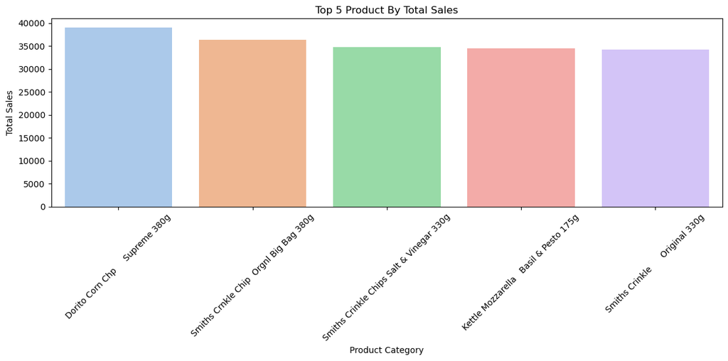

```python
#Show the bar chart of the Top 5 Product By Total Sales
plt.figure(figsize=(12,6))
sns.barplot(x='PROD_NAME', y='TOT_SALES',data=top_5_products, palette='pastel')
plt.xlabel('Product Category')
plt.ylabel('Total Sales')
plt.title('Top 5 Product By Total Sales')
plt.xticks(rotation=45)
plt.tight_layout()

#Show the plot
plt.show()
```

```python
#Calculate the value counts for the PREMIUM CUSTOMER column
premium_customer_counts = customer_df['PREMIUM_CUSTOMER'].value_counts()
premium_customer_counts
```

```
PREMIUM_CUSTOMER
Mainstream    29245
Budget        24470
Premium       18922
Name: count, dtype: int64
```

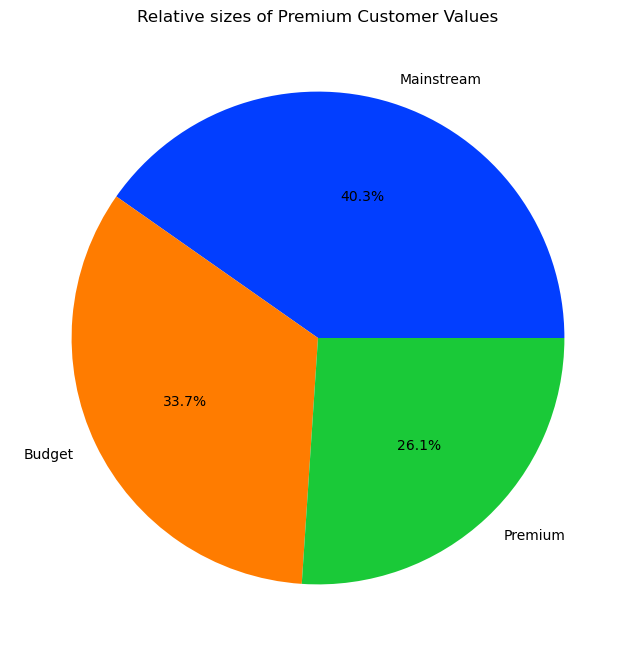

```python
plt.figure(figsize=(8,8))

premium_customer_counts.plot(kind='pie', autopct='%1.1f%%',  colors=sns.color_palette('bright'))

plt.title('Relative sizes of Premium Customer Values')
plt.ylabel('') #removes the default ylabel

#show the plot
plt.show()
```

```python
#Calculate total sales sold by store
total_sales_by_store = merged_df.groupby('STORE_NBR')['TOT_SALES'].sum().reset_index()

#Sort by total sales and get the top 5 stores
top_5_stores_by_sales = total_sales_by_store.sort_values(by='TOT_SALES', ascending = False).head(5)
top_5_stores_by_sales
```

|  | STORE_NBR | TOT_SALES |
| --- | --- | --- |
| 141 | 226 | 17605.45 |
| 259 | 88 | 16333.25 |
| 73 | 165 | 15973.75 |
| 207 | 40 | 15559.50 |
| 153 | 237 | 15539.50 |

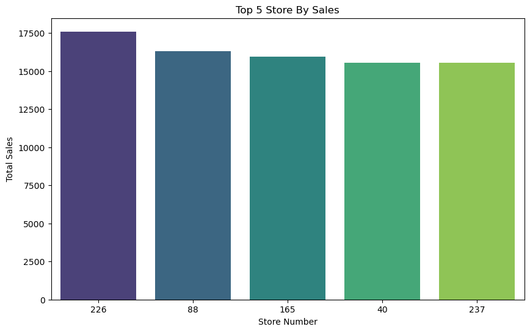

```python
#Plotting the bar graph
plt.figure(figsize=(10,6))

sns.barplot(x='STORE_NBR', y='TOT_SALES', data= top_5_stores_by_sales, palette='viridis')
plt.xlabel('Store Number')
plt.ylabel('Total Sales')
plt.title('Top 5 Store By Sales')

plt.show()
```

```python
#Calculate total quantity sold by store
total_qty_by_store = merged_df.groupby('STORE_NBR')['PROD_QTY'].sum().reset_index()

#Sort by total quantit and get the top 5 stores
top_5_stores_by_qty = total_qty_by_store.sort_values(by='PROD_QTY', ascending = False).head(5)
top_5_stores_by_qty
```

|  | STORE_NBR | PROD_QTY |
| --- | --- | --- |
| 141 | 226 | 4001 |
| 259 | 88 | 3718 |
| 265 | 93 | 3639 |
| 73 | 165 | 3602 |
| 210 | 43 | 3519 |

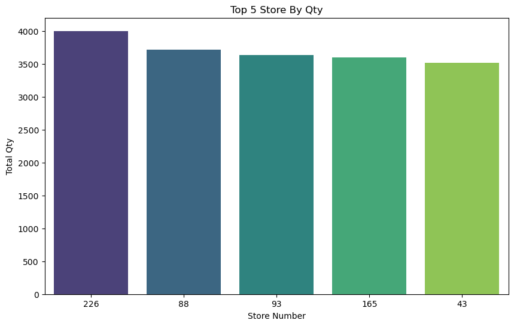

```python
#Plotting the bar graph
plt.figure(figsize=(10,6))

sns.barplot(x='STORE_NBR', y='PROD_QTY', data= top_5_stores_by_qty, palette='viridis')
plt.xlabel('Store Number')
plt.ylabel('Total Qty')
plt.title('Top 5 Store By Qty')

plt.show()
```

```python
#Calculate total sales per lifestage
sales_lifestage=merged_df.groupby('LIFESTAGE')['TOT_SALES'].sum().reset_index()
sales_lifestage.sort_values(by='TOT_SALES', ascending=False)
```

|  | LIFESTAGE | TOT_SALES |
| --- | --- | --- |
| 3 | OLDER SINGLES/COUPLES | 402426.75 |
| 4 | RETIREES | 366470.90 |
| 2 | OLDER FAMILIES | 352467.20 |
| 5 | YOUNG FAMILIES | 316160.10 |
| 6 | YOUNG SINGLES/COUPLES | 260405.30 |
| 0 | MIDAGE SINGLES/COUPLES | 184751.30 |
| 1 | NEW FAMILIES | 50433.45 |

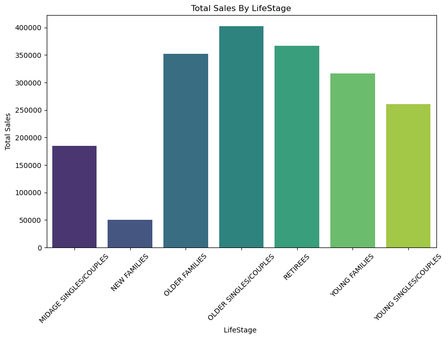

```python
#Plotting the bar graph
plt.figure(figsize=(10,6))

sns.barplot(x='LIFESTAGE', y='TOT_SALES', data= sales_lifestage, palette='viridis')
plt.xlabel('LifeStage ')
plt.ylabel('Total Sales')
plt.xticks(rotation=45)
plt.title('Total Sales By LifeStage')

plt.show()
```

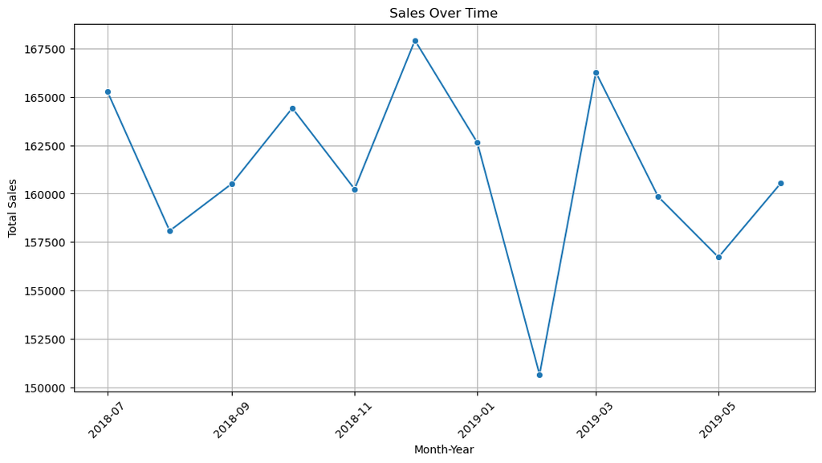

```python
#Create 'MONTH_YEAR' column
merged_df['MONTH_YEAR'] = merged_df['DATE'].dt.to_period('M').dt.to_timestamp()

#Calculate total Sales over Time
sales_over_time= merged_df.groupby('MONTH_YEAR')['TOT_SALES'].sum().reset_index()

# Plotting the line chart
plt.figure(figsize = (12,6))
sns.lineplot(x='MONTH_YEAR', y='TOT_SALES', data= sales_over_time, marker='o')
plt.xlabel('Month-Year')
plt.ylabel('Total Sales')
plt.title('Sales Over Time')
plt.grid(True)
plt.xticks(rotation=45)

#Show the plot
plt.show()
```

## 1.Key Measures

- **Total Sales**: $1,933,115
- **Total Quantity Sold**: 504,724 units
- **Total Unique Customers**: 72,637

--

## 2. Top Products by Sales

The five products with the highest sales revenue are:

| Product Name | Total Sales ($) |
| --- | --- |
| Dorito Corn Chip Supreme 380g | 39,052 |
| Smiths Crinkle Chip Original Big Bag 380g | 36,367.6 |
| Smiths Crinkle Chip Salt & Vinegar 330g | 34,804.2 |
| Kettle Mozzarella Basil & Pesto 175g | 34,457.4 |
| Smiths Crinkle Original 330g | 34,302.6 |

## 3. Customer Count By Spending Category

Customer count per spending category

| Category | Customer Count |
| --- | --- |
| Nainstream | 29,245 |
| Budget | 24,470 |
| Premium | 18,922 |

## 4. Top Stores by Sales and Quantity

[output not shown]

### Quantity Leaders

[output not shown]

## 5. Monthly Sales Trends

We have noticed a pick of sales on December 2018 at 167,913.4, likely because of the holidays season. and also we have a significant drop the occured on February 2019 due the End of Holiday season.

## 6. Sales Breakdown by Life Stage

presentation according to the lifestage to following stage bearkdown:

| Life Stage | Total Sales ($ |
| --- | --- |
| Order singles/Couples | 402426.75 |
| Retirees | 366470.90 |
| Older Families | 352467.20 |
| Young Families | 316160.10 |
| Young Singles/Couples | 260405.30 |
| Mid Age Singles/Couples | 184751.30 |
| New Families | 50433.45 |

**Key Insight**: Order singles/couples and retirees are the principals contributord to sales.In conclusion, they are the key customer segments.

## 7. Recommendations

### **Focus on Key Customer Segments**

**Order Singles/Couples & Retirees**: - These segments contribute the most to sales. Implement targeted marketing campaigns offering promotions or discounts tailored to their preferences.

For example: - Bundle deals for single households. - Discounts on frequently purchased products like snacks for retirees.

**Young Families**: This segment has significant sales potential but ranks fourth. Offer family-oriented promotions such as "Buy More, Save More" deals on family-sized products.

### **Expand Availability of Top-Selling Products**

```
      - Ensure top products like Dorito Corn Chip Supreme 380g and Smiths Crinkle Chip Original Big Bag 380g are consistently in stock across all stores.
      - Promote these items with prominent in-store placement and online advertisements.
```

### **Optimize Store Performance**

**Top-Performing Stores (e.g., Store 226)**: Study their operational strategies (e.g., layout, customer service, local demand patterns) and replicate successful practices in other stores.

**Low-Performing Stores**: Identify underperforming stores and address challenges such as poor product variety, low inventory, or ineffective marketing.

### **Seasonal Sales Strategy**

**Peak in December**: Capitalize on the holiday season by running aggressive marketing campaigns and stocking high-demand products.

**Drop in February**: Introduce post-holiday promotions to maintain customer interest and sales momentum. For example: - Loyalty programs to encourage repeat purchases. - Discounts on products with slower turnover during this period.

### **Leverage Spending Categories**

**Mainstream Customers**: As the largest group, target them with consistent value offerings and mid-range promotions.

**Budget Customers**: Offer affordable bundles and loyalty rewards to encourage repeat visits and purchases.

**Premium Customers**: Focus on exclusive products and premium experiences (e.g., limited editions, gourmet snacks).

### **Improve Product Assortment for Life Stages**

**Young Singles/Couples & Mid-Age Singles/Couples**: Develop snack packs, meal kits, or convenience-oriented products appealing to these groups.

**New Families**: Introduce promotions for essential baby and child-related items or groceries tailored for young families.

### **Enhance Monthly Sales Trend Monitoring**

**Use insights from monthly trends to**: - Anticipate and prepare for demand spikes. - Implement targeted strategies during expected slow months to maintain consistent sales.

By implementing these strategies, the business can better align with customer needs, enhance store efficiency, and drive higher revenue.